# 3_NOTEBOOK

```python
from src.data.config_reader import *
from src.data.path_finder import *
from src.data.database_configurations import *

import pandas as pd
import numpy as np
from matplotlib import pyplot as plt

from sklearn.feature_extraction.text import CountVectorizer, TfidfVectorizer
from sklearn.metrics.pairwise import cosine_similarity

import mlflow
from pycaret.classification import *

pd.set_option('display.float_format', lambda x: '%.3f' % x)
plt.rcParams["figure.figsize"] = (12,7)
```

```python
# Creating an SQLite database into which we can consolidate the seperate csv files as SQL tables
initiate_database()
```

```
Target db exists  moving on to table building operation...
```

```python
# Access database
conn = connect_db()
```

## Getting to know the data

### Product table

```python
df = pd.read_sql("SELECT * FROM df_product", conn)
print(df.shape)
```

```
(1441753, 7)
```

```python
# Gender and Age variables have a great deal of missing values
(df.isnull().sum() / df.shape[0] * 100).sort_values(ascending=False) # P.S: values are in percent.
```

```
age                  21.585
gender               15.369
title                 0.041
contentid             0.000
currentbugroupname    0.000
brandid               0.000
categoryname          0.000
dtype: float64
```

#### Brand Distribution

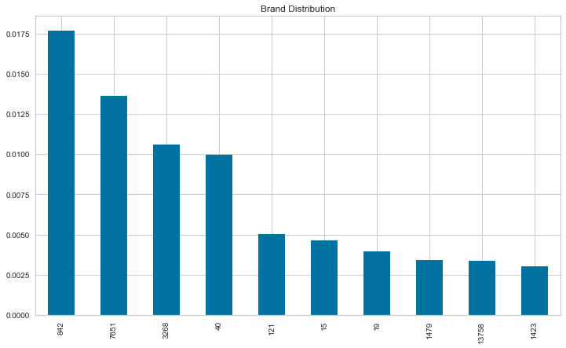

```python
df.brandid.value_counts(normalize=True, ascending=False).head(10).plot(kind='bar', title="Brand Distribution");
```

**Interesting insight:** Top 4 Brands owns around %5 percent of the products in the marketplace

#### Gender Distribution

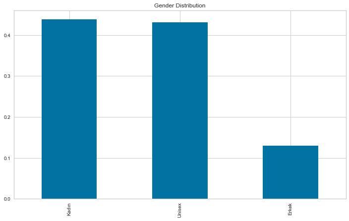

```python
# Seems like it's the women's world!
# Gender will be an important feature in the model apparently
df.gender.value_counts(normalize=True, ascending=False).plot(kind='bar', title="Gender Distribution");
```

### Demographics table

#### Gender Distribution

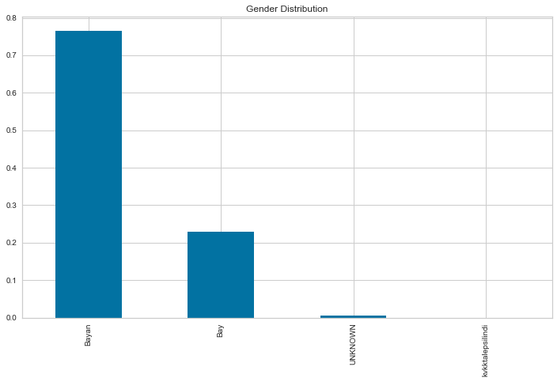

```python
df = pd.read_sql("SELECT * FROM df_demo", conn)
df.gender.value_counts(normalize=True, ascending=False).plot(kind='bar', title="Gender Distribution");
```

Demand meets supply here. Gender will certainly be of immense importance!

## Data Manipulation and Cleaning

The aim is to transform the original train dataset into a binary classification suitable format. The original data consists only of the purchases **made** by the users. In other words the data does not contain label "0".

To overcome this problem, I have applied some manipulation techniques to join non-present **currentbugroupname** values to the original data; since non-presence indicates that the user did not purchase any thing with the given **currentbugroupname** label.

```python
# Here we start manipulating the train dataset
df_target_train = pd.read_sql("SELECT * FROM df_target_train", conn)
df_target_train["userid"] = df_target_train["userid"].astype(str)
df_target_train.sort_values("userid", inplace=True)
df_target_train.dropna(subset=["currentbugroupname"], inplace=True)
```

```python
# We now instantiate an empty DataFrame that will end up containing all the currentbugroupname combinations for each user
df_target_train_cleaned = pd.DataFrame()

# Storing unique userids and groupnames in order to create all "userid - currentbugroupname" scenarios
df_target_train_cleaned["userid"] = df_target_train["userid"].sort_values().unique()
df_target_train_cleaned["groupname"] = [df_target_train["currentbugroupname"].sort_values().unique().tolist()] * df_target_train_cleaned["userid"].nunique()
df_target_train_cleaned = df_target_train_cleaned.explode("groupname").sort_values("userid").reset_index(drop=True)
df_target_train_cleaned.sort_values(["userid"], inplace=True)
df_target_train_cleaned.reset_index(drop=True, inplace=True)
```

```python
groupname_list = df_target_train["currentbugroupname"].sort_values().unique().tolist()
```

```python
# After creating a synthetic train dataset we can gather the purchase information from the original data
# and use the information to label the corresponding rows as "1"
merged = pd.merge(df_target_train, df_target_train_cleaned, how='left', on=['userid'])
merged.sort_values("userid", inplace=True)

# Necessary operations to align the group names and purchases
# (i.e, if the user purchased an FMCG product the label will be "1")
merged["bol"] = merged.groupby(["userid", "currentbugroupname"]).currentbugroupname.transform(lambda x: x.duplicated())
merged["currentbugroupname"] = merged.apply(lambda x: np.nan if x["bol"] else x["currentbugroupname"], axis=1)
merged.reset_index(drop=True, inplace=True)
merged["y"] = merged.groupby("userid").apply(lambda x: x["groupname"].isin(x["currentbugroupname"])).reset_index()["groupname"].replace({True:1, False:0})

merged.drop(columns=["bol", "currentbugroupname"], inplace=True)
merged.drop_duplicates(subset=["userid", "groupname"], inplace=True)
merged.rename(columns={"groupname": "currentbugroupname"}, inplace=True)
```

```python
# Notice that all 12 distinct groupnames are labeled accordingly for each user
merged.head(14)
```

|  | userid | currentbugroupname | y |
| --- | --- | --- | --- |
| 0 | 10000270 | Aksesuar & Saat & Gözlük | 0 |
| 1 | 10000270 | FMCG | 1 |
| 2 | 10000270 | Private Label | 0 |
| 3 | 10000270 | Kozmetik | 0 |
| 4 | 10000270 | GAS | 0 |
| 5 | 10000270 | Digital Goods | 0 |
| 6 | 10000270 | Mobilya | 0 |
| 7 | 10000270 | Elektronik | 0 |
| 8 | 10000270 | Branded Tekstil | 0 |
| 9 | 10000270 | Ayakkabı & Çanta | 0 |
| 10 | 10000270 | Ev | 0 |
| 11 | 10000270 | GM | 0 |
| 12 | 10000452 | Ev | 0 |
| 13 | 10000452 | Kozmetik | 0 |

```python
# Upon obtaining a suitable dataframe, we can start connecting other tables in the db
# To this end we will create a dictionary that will provide a valid currentbugroupname for each content in the database
df_products = pd.read_sql("SELECT contentid, currentbugroupname FROM df_product", conn)
df_products.head()
```

|  | contentid | currentbugroupname |
| --- | --- | --- |
| 0 | 40100964 | Ayakkabı & Çanta |
| 1 | 40427970 | Branded Tekstil |
| 2 | 41026644 | FMCG |
| 3 | 41227029 | Branded Tekstil |
| 4 | 40770080 | Ev |

```python
products_dict = df_products.set_index("contentid").to_dict("dict")["currentbugroupname"]
```

```python
# Now we can use this dictionary to create a currentbugroupname column in each table that contains contentid
m = merged.copy()

# We will use a for loop to iterate over the tables to link the contents to the group names and join the tables each other
for table in ["df_demo", "df_basket", "df_visit", "df_trx", "df_fav"]:
    df_table = pd.read_sql(f"SELECT * FROM {table}", conn)
    df_table["userid"] = df_table["userid"].astype(str)

    # Demographical data does not contain content, thus it will be handled with an else statement
    if table != "df_demo":
        df_table["currentbugroupname"] = df_table["contentid"].map(products_dict)
        df_table = df_table.groupby(["userid", "currentbugroupname"]).sum().reset_index().drop(columns=["contentid"])
        column_names = [f'{k}_{table.replace("df_", "")}' if k not in ["userid", "currentbugroupname"] else k for k in df_table.columns]
        df_table.columns = column_names
        m = m.merge(df_table, on=["userid", "currentbugroupname"], how="left")
    else:
        df_table["gender"].str.replace("kvkktalepsilindi", "UNKNOWN")
        df_table["age"] = np.where(df_table["age"]>100, np.nan, df_table["age"])
        df_table["age"] = np.where(df_table["age"]<5, np.nan, df_table["age"])
        m = m.merge(df_table, on=["userid"], how="left")
```

```python
# Table "m" seems more eligible for the task at hand now!
m.head()
```

|  | userid | currentbugroupname | y | gender | age | tenure | addtobasket_count_basket | productdetailcount_visit | quantity_trx | price_trx | fav_count_fav |
| --- | --- | --- | --- | --- | --- | --- | --- | --- | --- | --- | --- |
| 0 | 10000270 | Aksesuar & Saat & Gözlük | 0 | Bayan | 39.000 | 85 | NaN | NaN | NaN | NaN | NaN |
| 1 | 10000270 | FMCG | 1 | Bayan | 39.000 | 85 | NaN | 33.000 | NaN | NaN | NaN |
| 2 | 10000270 | Private Label | 0 | Bayan | 39.000 | 85 | NaN | 4.000 | NaN | NaN | NaN |
| 3 | 10000270 | Kozmetik | 0 | Bayan | 39.000 | 85 | NaN | 6.000 | NaN | NaN | NaN |
| 4 | 10000270 | GAS | 0 | Bayan | 39.000 | 85 | NaN | 1.000 | NaN | NaN | NaN |

```python
# Imputing nan values
na_columns = m.select_dtypes(include=np.number).drop(columns=["age", "y"])
na_columns.fillna(0, inplace=True)
m.loc[:, na_columns.columns] = na_columns
m
```

|  | userid | currentbugroupname | y | gender | age | tenure | addtobasket_count_basket | productdetailcount_visit | quantity_trx | price_trx | fav_count_fav |
| --- | --- | --- | --- | --- | --- | --- | --- | --- | --- | --- | --- |
| 0 | 10000270 | Aksesuar & Saat & Gözlük | 0 | Bayan | 39.000 | 85 | 0.000 | 0.000 | 0.000 | 0.000 | 0.000 |
| 1 | 10000270 | FMCG | 1 | Bayan | 39.000 | 85 | 0.000 | 33.000 | 0.000 | 0.000 | 0.000 |
| 2 | 10000270 | Private Label | 0 | Bayan | 39.000 | 85 | 0.000 | 4.000 | 0.000 | 0.000 | 0.000 |
| 3 | 10000270 | Kozmetik | 0 | Bayan | 39.000 | 85 | 0.000 | 6.000 | 0.000 | 0.000 | 0.000 |
| 4 | 10000270 | GAS | 0 | Bayan | 39.000 | 85 | 0.000 | 1.000 | 0.000 | 0.000 | 0.000 |
| ... | ... | ... | ... | ... | ... | ... | ... | ... | ... | ... | ... |
| 216595 | 9998688 | Kozmetik | 0 | Bayan | 31.000 | 85 | 0.000 | 4.000 | 0.000 | 0.000 | 1.000 |
| 216596 | 9998688 | Mobilya | 0 | Bayan | 31.000 | 85 | 0.000 | 5.000 | 0.000 | 0.000 | 0.000 |
| 216597 | 9998688 | GAS | 0 | Bayan | 31.000 | 85 | 0.000 | 13.000 | 0.000 | 0.000 | 3.000 |
| 216598 | 9998688 | Private Label | 1 | Bayan | 31.000 | 85 | 0.000 | 351.000 | 1.000 | 48.990 | 35.000 |
| 216599 | 9998688 | Ev | 0 | Bayan | 31.000 | 85 | 0.000 | 29.000 | 0.000 | 0.000 | 0.000 |

216600 rows × 11 columns

```python
m.isnull().sum()
```

```
userid                           0
currentbugroupname               0
y                                0
gender                           0
age                         121728
tenure                           0
addtobasket_count_basket         0
productdetailcount_visit         0
quantity_trx                     0
price_trx                        0
fav_count_fav                    0
dtype: int64
```

```python
m.to_csv("input_data/processed/clean_data.csv", index=False)
```

## Feature Generation

Search terms table carries a great deal of potential to encrich the dataset. We first need to use text vectorization techniques to create a structural data. To this end we will use **Term Frequency–Inverse Document Frequency (TFIDF)**. Simply put, we will try to match the search terms with the content category names so that we can see if a searching event can be linked to a content in the df_products table.

Experimenting with other techniques such as **Siamese Neural Nets** would worth trying

```python
# Get category names from the product table
df_cats = pd.read_sql("SELECT categoryname FROM df_product", conn)
df_cats = df_cats.dropna().drop_duplicates()
df_cats = df_cats.replace("[^\w ]", "", regex=True)
print(df_cats.shape)
```

```
(2529, 1)
```

```python
# Get search terms
df_search = pd.read_sql("SELECT * FROM df_search_term", conn)
df_search = df_search.dropna().drop_duplicates(subset=["search_term"]).query("search_term != 'tum urunler'")
df_search = df_search.replace("[^\w ]", "", regex=True)
df_search.shape
```

```
(373425, 3)
```

```python
# Initialize a TFIDF vectorizer to create structural text data
vectorizer_ntf = TfidfVectorizer(analyzer='word', ngram_range=(1, 3))

# Transform both Vector 1 (Category Names) and Vector 2 (Search Terms)
X_ntf_cats = vectorizer_ntf.fit_transform(df_cats["categoryname"].to_numpy())
X_ntf_search = vectorizer_ntf.transform(df_search["search_term"].to_numpy())
```

```python
# Calculate cosine similarities of each pair
X_ntf = cosine_similarity(X_ntf_search, X_ntf_cats)
X_ntf.shape
```

```
(373425, 2529)
```

```python
# The data occupies a huge area in the memory so we try to get rid of the unsignificant rows/columns with 0 score
df_similarity = pd.concat([pd.DataFrame(X_ntf,index=df_search["search_term"], columns=df_cats["categoryname"])],axis=1).replace(0, np.nan)
df_similarity.dropna(how="all", inplace=True)
df_similarity.dropna(how="all", inplace=True, axis=1)
df_similarity.shape
```

```
(208791, 2487)
```

```python
# En example of a matching pair (e.g., "Kazak" and "ananaslı kazak")
a = "ananaslı kazak"
df_similarity.loc[a].sort_values(ascending=False).head()
```

```
categoryname
Kazak               1.000
Tesettür Kazak      0.608
Büyük Beden Kazak   0.444
Klasik Ayakkabı       NaN
Pantolon              NaN
Name: ananaslı kazak, dtype: float64
```

```python
# We now make some changes in the dataframe to fit it into a dictionary format for later use
melted = df_similarity.reset_index().melt(id_vars="search_term", value_vars=[k for k in df_similarity.columns if k != "search_term"]).dropna(subset=["value"])
melted = melted.query("value >= 0.15").sort_values(["search_term", "value"], ascending=False)
melted["rank"] = 1
melted["num"] = melted.groupby("search_term")["rank"].transform(np.cumsum)
melted = melted.query("num < 4")[["search_term", "categoryname"]]
melted.head()
```

|  | search_term | categoryname |
| --- | --- | --- |
| 255824352 | əl kol diz dirsək ağrıları | Kol Düğmesi |
| 162034741 | űstű dolap alti cekmece | Dolap ve Gardrop |
| 59291071 | şşn musluk | Batarya Musluk |
| 94844666 | şırınga model kalem | Model Araçlar |
| 327437840 | şırınga model kalem | Kalem Setleri |

```python
# Since we see that some of the terms are matched with some category names, this can lead us to connecting search terms
# to product table which eventually be useful to create a new feature in the target table
search_term_dict = melted.set_index("search_term").to_dict("dict")["categoryname"]
search_term_dict["şık yüz maskesi"]
```

```
'Yüz Temizleyici'
```

```python
# Search terms are replaced with category names to create implicit representations of search terms
df_search["target_categoryname"] = df_search["search_term"].map(search_term_dict)
```

```python
df_products = pd.read_sql("SELECT categoryname, currentbugroupname FROM df_product", conn)
df_products.head()
```

|  | categoryname | currentbugroupname |
| --- | --- | --- |
| 0 | Klasik Ayakkabı | Ayakkabı & Çanta |
| 1 | Pantolon | Branded Tekstil |
| 2 | Akvaryum Balık Yemleri | FMCG |
| 3 | Külot | Branded Tekstil |
| 4 | Tabak | Ev |

```python
products_dict = df_products.set_index("categoryname").to_dict("dict")["currentbugroupname"]
products_dict["Pantolon"]
```

```
'Branded Tekstil'
```

```python
# Now we can match implicit representations of search terms with the product table
df_search["currentbugroupname"] = df_search["target_categoryname"].map(products_dict)
```

```python
# Aggregating the values by summation
df_final = df_search.groupby(["userid", "currentbugroupname"], as_index=False).agg({"partition_date": "count"}).rename(columns={"partition_date": "search_count"})
df_final["userid"] = df_final["userid"].astype(str)
```

```python
df_final.head()
```

|  | userid | currentbugroupname | search_count |
| --- | --- | --- | --- |
| 0 | 12810 | Aksesuar & Saat & Gözlük | 1 |
| 1 | 12810 | GAS | 2 |
| 2 | 12810 | Kozmetik | 1 |
| 3 | 15148 | Ev | 1 |
| 4 | 23198 | FMCG | 1 |

```python
# Read the main (train dataset) and merge it with the newly created dataframe
df = pd.read_csv("input_data/processed/clean_data.csv")
df["userid"] = df["userid"].astype(str)
df = df.merge(df_final, on=["userid", "currentbugroupname"], how="left")
```

### Zen Score

This is a crafted feature that aims to catch a non-linear interaction. In the simplest form, this score indicates if there is a specific bugroupname or bugroupnames that the customer keeps viewing or else is he/she actively wandering around the platform without focusing on a product within a day. This will simply tell the extent of which the user focused on specific kinds of products.

**The formula is as follows:**

## $(1 - views \div total)^2$

A number close to 1 means a Zen day (e.g., looking for a specific product) and a number closer to 0 means the user does not look for something specific.

Upon calculating the Zen Scores of each user in a given day, now it's time to calculate the number of Zen days and determine if the target currentbugroupname value is in the visit history of the user.

```python
# Get the product viewing data with 'currentbugroupname' variable joined
df_visits = pd.read_sql("""
WITH cte AS
    (
    SELECT df_visit.*, df_product.currentbugroupname FROM df_visit
    LEFT JOIN df_product ON df_visit.contentid = df_product.contentid
    )

SELECT * FROM cte WHERE currentbugroupname IS NOT NULL
""", conn)

df_visits["partition_date"] = pd.to_datetime(df_visits["partition_date"])
df_visits.set_index("partition_date", inplace=True)

# Groupby using 'userid' and 'partition_date' variables calculate total numbers of views and
# number of unique 'currentbugroupnames' in addition to corresponding group names each day
df_visits = df_visits.groupby(["userid",pd.Grouper(freq="D")]).agg(
    {
        "productdetailcount": "sum",
        "currentbugroupname": ["nunique", ("unique_groups", lambda x: list(set(x))[:5])]
    }
)

# Flattening column levels
df_visits.columns =  ["_".join(col_name).rstrip('_') for col_name in df_visits.columns.to_flat_index()]

# Finally calculate the zen ratio
df_visits["zen_ratio"] = df_visits.apply(lambda x: (1 - x["currentbugroupname_nunique"] / x["productdetailcount_sum"]) ** 2, axis=1)
df_visits.head()
```

| userid | partition_date | productdetailcount_sum | currentbugroupname_nunique | currentbugroupname_unique_groups | zen_ratio |
| --- | --- | --- | --- | --- | --- |
| 12810 | 2020-10-03 | 26 | 3 | [Ayakkabı & Çanta, Private Label, Branded Teks... | 0.783 |
|  | 2020-10-04 | 6 | 4 | [Ev, Ayakkabı & Çanta, Private Label, GAS] | 0.111 |
|  | 2020-10-05 | 40 | 5 | [Ayakkabı & Çanta, GM, GAS, Branded Tekstil, P... | 0.766 |
|  | 2020-10-06 | 266 | 10 | [Mobilya, Ayakkabı & Çanta, GM, Kozmetik, Ev] | 0.926 |
|  | 2020-10-07 | 1 | 1 | [Branded Tekstil] | 0.000 |

```python
### Now, we will calculate mean zen_ratio for each user-currentbugroupname pairs
# 1- First we need to "explode" the list of unique currentbugroupname names across rows to obtain user-groupname pairs
df_visits_mean = df_visits.explode("currentbugroupname_unique_groups")
df_visits_mean.head()
```

| userid | partition_date | productdetailcount_sum | currentbugroupname_nunique | currentbugroupname_unique_groups | zen_ratio |
| --- | --- | --- | --- | --- | --- |
| 12810 | 2020-10-03 | 26 | 3 | Ayakkabı & Çanta | 0.783 |
|  | 2020-10-03 | 26 | 3 | Private Label | 0.783 |
|  | 2020-10-03 | 26 | 3 | Branded Tekstil | 0.783 |
|  | 2020-10-04 | 6 | 4 | Ev | 0.111 |
|  | 2020-10-04 | 6 | 4 | Ayakkabı & Çanta | 0.111 |

```python
# 2- Using pivot_table calculate the corresponding zen ratio mean for each pairs
df_visits_mean = df_visits_mean.pivot_table(index="userid", columns="currentbugroupname_unique_groups", values="zen_ratio", aggfunc="mean").reset_index()
df_visits_mean.head()
```

| currentbugroupname_unique_groups | userid | Aksesuar & Saat & Gözlük | Ayakkabı & Çanta | Branded Tekstil | Digital Goods | Elektronik | Ev | FMCG | GAS | GM | Kozmetik | Mobilya | Private Label | UNKNOWN |
| --- | --- | --- | --- | --- | --- | --- | --- | --- | --- | --- | --- | --- | --- | --- |
| 0 | 12810 | 0.460 | 0.678 | 0.712 | NaN | NaN | 0.668 | 0.521 | 0.731 | 0.753 | 0.847 | 0.770 | 0.701 | NaN |
| 1 | 14302 | NaN | 0.900 | NaN | NaN | 0.450 | NaN | NaN | 0.444 | 0.000 | NaN | NaN | NaN | NaN |
| 2 | 15148 | 0.379 | 0.802 | 0.754 | NaN | 0.476 | 0.459 | 0.670 | 0.664 | 0.791 | 0.623 | 0.591 | 0.467 | NaN |
| 3 | 23198 | 0.574 | 0.125 | 0.557 | NaN | 0.360 | 0.584 | 0.526 | 0.427 | 0.548 | 0.481 | NaN | 0.508 | NaN |
| 4 | 25005 | 0.396 | 0.727 | 0.681 | NaN | NaN | 0.603 | 0.716 | 0.766 | 0.700 | 0.538 | 0.700 | 0.483 | NaN |

```python
# 3- Convert the table from wide format to long format
df_visits_mean = df_visits_mean.melt(id_vars=["userid"], value_vars=[k for k in df_visits_mean.columns if k != "userid"], value_name="zen_mean").dropna(subset=["zen_mean"])
df_visits_mean["userid"] = df_visits_mean["userid"].astype(str)
df_visits_mean.head()
```

|  | userid | currentbugroupname_unique_groups | zen_mean |
| --- | --- | --- | --- |
| 0 | 12810 | Aksesuar & Saat & Gözlük | 0.460 |
| 2 | 15148 | Aksesuar & Saat & Gözlük | 0.379 |
| 3 | 23198 | Aksesuar & Saat & Gözlük | 0.574 |
| 4 | 25005 | Aksesuar & Saat & Gözlük | 0.396 |
| 6 | 28742 | Aksesuar & Saat & Gözlük | 0.759 |

```python
# 4- Repeat the same procedure for the number of zen days count
df_visits_count = df_visits.explode("currentbugroupname_unique_groups").pivot_table(index="userid", columns="currentbugroupname_unique_groups", values="zen_ratio", aggfunc="count").reset_index()
df_visits_count = df_visits_count.melt(id_vars=["userid"], value_vars=[k for k in df_visits_count.columns if k != "userid"], value_name="zen_count").dropna(subset=["zen_count"])
df_visits_count["userid"] = df_visits_count["userid"].astype(str)
```

```python
# 5- Finally merge both tables with the main table
df = df.merge(df_visits_mean, left_on=["userid","currentbugroupname"] ,right_on=["userid", "currentbugroupname_unique_groups"], how="left")
df.drop(columns=["currentbugroupname_unique_groups"], inplace=True)
df["zen_mean"] = df["zen_mean"].fillna(0)

df = df.merge(df_visits_count, left_on=["userid","currentbugroupname"] ,right_on=["userid", "currentbugroupname_unique_groups"], how="left")
df.drop(columns=["currentbugroupname_unique_groups"], inplace=True)
df["zen_count"] = df["zen_count"].fillna(0)
df.head()
```

|  | userid | currentbugroupname | y | gender | age | tenure | addtobasket_count_basket | productdetailcount_visit | quantity_trx | price_trx | fav_count_fav | search_count | zen_mean | zen_count |
| --- | --- | --- | --- | --- | --- | --- | --- | --- | --- | --- | --- | --- | --- | --- |
| 0 | 10000270 | Aksesuar & Saat & Gözlük | 0 | Bayan | 39.000 | 85 | 0.000 | 0.000 | 0.000 | 0.000 | 0.000 | NaN | 0.000 | 0.000 |
| 1 | 10000270 | FMCG | 1 | Bayan | 39.000 | 85 | 0.000 | 33.000 | 0.000 | 0.000 | 0.000 | NaN | 0.562 | 7.000 |
| 2 | 10000270 | Private Label | 0 | Bayan | 39.000 | 85 | 0.000 | 4.000 | 0.000 | 0.000 | 0.000 | NaN | 0.503 | 2.000 |
| 3 | 10000270 | Kozmetik | 0 | Bayan | 39.000 | 85 | 0.000 | 6.000 | 0.000 | 0.000 | 0.000 | NaN | 0.350 | 3.000 |
| 4 | 10000270 | GAS | 0 | Bayan | 39.000 | 85 | 0.000 | 1.000 | 0.000 | 0.000 | 0.000 | NaN | 0.000 | 1.000 |

```python
df.to_csv("input_data/processed/processed_data.csv", index=False)
```

# Model Training

```python
# Read the cleaned and feature engineered train data
df = pd.read_csv("input_data/processed/processed_data.csv")
df.drop(columns=["userid", "currentbugroupname", "price_trx"], inplace=True)
df.loc[:, "tenure":] = df.loc[:, "tenure":].fillna(0)
```

```python
# Read the cleaned and feature engineered test data
df_test = pd.read_sql("SELECT * FROM df_test_final", conn)
df_test.loc[:, "tenure":] = df_test.loc[:, "tenure":].fillna(0)
```

```python
df.head()
```

|  | y | gender | age | tenure | addtobasket_count_basket | productdetailcount_visit | quantity_trx | fav_count_fav | search_count | zen_mean | zen_count |
| --- | --- | --- | --- | --- | --- | --- | --- | --- | --- | --- | --- |
| 0 | 0 | Bayan | 39.000 | 85 | 0.000 | 0.000 | 0.000 | 0.000 | 0.000 | 0.000 | 0.000 |
| 1 | 1 | Bayan | 39.000 | 85 | 0.000 | 33.000 | 0.000 | 0.000 | 0.000 | 0.562 | 7.000 |
| 2 | 0 | Bayan | 39.000 | 85 | 0.000 | 4.000 | 0.000 | 0.000 | 0.000 | 0.503 | 2.000 |
| 3 | 0 | Bayan | 39.000 | 85 | 0.000 | 6.000 | 0.000 | 0.000 | 0.000 | 0.350 | 3.000 |
| 4 | 0 | Bayan | 39.000 | 85 | 0.000 | 1.000 | 0.000 | 0.000 | 0.000 | 0.000 | 1.000 |

```python
df_test.head()
```

|  | userid | currentbugroupname | gender | age | tenure | addtobasket_count_basket | productdetailcount_visit | quantity_trx | fav_count_fav | search_count | zen_mean | zen_count |
| --- | --- | --- | --- | --- | --- | --- | --- | --- | --- | --- | --- | --- |
| 0 | 10000970 | Aksesuar & Saat & Gözlük | Bayan | 50.000 | 85 | 0.000 | 336.000 | 2.000 | 45.000 | 3.000 | 0.761 | 14.000 |
| 1 | 10000970 | Kozmetik | Bayan | 50.000 | 85 | 0.000 | 138.000 | 3.000 | 9.000 | 0.000 | 0.801 | 5.000 |
| 2 | 10000970 | Mobilya | Bayan | 50.000 | 85 | 0.000 | 0.000 | 0.000 | 0.000 | 0.000 | 0.000 | 0.000 |
| 3 | 10000970 | Private Label | Bayan | 50.000 | 85 | 0.000 | 19.000 | 0.000 | 2.000 | 0.000 | 0.768 | 5.000 |
| 4 | 10000970 | FMCG | Bayan | 50.000 | 85 | 0.000 | 4.000 | 0.000 | 0.000 | 0.000 | 0.760 | 2.000 |

```python
# Instantiate PyCaret classifier
clf = setup(data=df,

            # target variable
            target='y',

            # K-Fold CV parameter: 10-Fold CV applied just to ensure reliability
            fold = 10,

            # Applies scaling to the train data using zscore
            normalize=True,

            # Age variable is not highly sensitive to small variations, so binning might help improve accuracy
            # (e.g., 20 yo - 23 yo would not mean much whereas 20 yo and 30 yo exhibits drastic differences
            bin_numeric_features=["age"],

            # The data is heavily imbalanced thus SMOTE will be applied to maintain the balance
            fix_imbalance=True,

            # The data is heavily woman oriented thus we can use stratification to balance train test split data
            data_split_stratify=["gender"],
            use_gpu=True,
            session_id=1)


### THINGS TO NOTE ###

# 1- Pycaret handles categorical data so we don't need to factorize "gender" variable

# 2- "age" column has a lot of missing data which we can have Pycaret  with it.
# ... However applying KNN Imputer might be another option to consider.

# 3- Feature Engineering operations can be enriched by labeling special days like "Black Friday".
```

|  | Description | Value |
| --- | --- | --- |
| 0 | session_id | 1 |
| 1 | Target | y |
| 2 | Target Type | Binary |
| 3 | Label Encoded | None |
| 4 | Original Data | (216600, 11) |
| 5 | Missing Values | True |
| 6 | Numeric Features | 9 |
| 7 | Categorical Features | 1 |
| 8 | Ordinal Features | False |
| 9 | High Cardinality Features | False |
| 10 | High Cardinality Method | None |
| 11 | Transformed Train Set | (151619, 31) |
| 12 | Transformed Test Set | (64981, 31) |
| 13 | Shuffle Train-Test | True |
| 14 | Stratify Train-Test | ['gender'] |
| 15 | Fold Generator | StratifiedKFold |
| 16 | Fold Number | 10 |
| 17 | CPU Jobs | -1 |
| 18 | Use GPU | True |
| 19 | Log Experiment | False |
| 20 | Experiment Name | clf-default-name |
| 21 | USI | 7644 |
| 22 | Imputation Type | simple |
| 23 | Iterative Imputation Iteration | None |
| 24 | Numeric Imputer | mean |
| 25 | Iterative Imputation Numeric Model | None |
| 26 | Categorical Imputer | constant |
| 27 | Iterative Imputation Categorical Model | None |
| 28 | Unknown Categoricals Handling | least_frequent |
| 29 | Normalize | True |
| 30 | Normalize Method | zscore |
| 31 | Transformation | False |
| 32 | Transformation Method | None |
| 33 | PCA | False |
| 34 | PCA Method | None |
| 35 | PCA Components | None |
| 36 | Ignore Low Variance | False |
| 37 | Combine Rare Levels | False |
| 38 | Rare Level Threshold | None |
| 39 | Numeric Binning | True |
| 40 | Remove Outliers | False |
| 41 | Outliers Threshold | None |
| 42 | Remove Multicollinearity | False |
| 43 | Multicollinearity Threshold | None |
| 44 | Remove Perfect Collinearity | True |
| 45 | Clustering | False |
| 46 | Clustering Iteration | None |
| 47 | Polynomial Features | False |
| 48 | Polynomial Degree | None |
| 49 | Trignometry Features | False |
| 50 | Polynomial Threshold | None |
| 51 | Group Features | False |
| 52 | Feature Selection | False |
| 53 | Feature Selection Method | classic |
| 54 | Features Selection Threshold | None |
| 55 | Feature Interaction | False |
| 56 | Feature Ratio | False |
| 57 | Interaction Threshold | None |
| 58 | Fix Imbalance | True |
| 59 | Fix Imbalance Method | SMOTE |

```python
# Run all the model and compare across different metrics (KNN method is removed due to being a overly exhaustive model)
best = compare_models(exclude=["knn"])
```

|  | Model | Accuracy | AUC | Recall | Prec. | F1 | Kappa | MCC | TT (Sec) |
| --- | --- | --- | --- | --- | --- | --- | --- | --- | --- |
| dummy | Dummy Classifier | 0.8855 | 0.5000 | 0.0000 | 0.0000 | 0.0000 | 0.0000 | 0.0000 | 6.2730 |
| xgboost | Extreme Gradient Boosting | 0.8799 | 0.6407 | 0.0962 | 0.4000 | 0.1549 | 0.1157 | 0.1507 | 8.0330 |
| lightgbm | Light Gradient Boosting Machine | 0.8757 | 0.6720 | 0.1347 | 0.3798 | 0.1988 | 0.1477 | 0.1713 | 8.6800 |
| rf | Random Forest Classifier | 0.8491 | 0.6467 | 0.1792 | 0.2652 | 0.2138 | 0.1338 | 0.1370 | 23.4710 |
| catboost | CatBoost Classifier | 0.8457 | 0.6649 | 0.2321 | 0.2858 | 0.2561 | 0.1711 | 0.1723 | 20.0730 |
| et | Extra Trees Classifier | 0.8398 | 0.6535 | 0.2112 | 0.2571 | 0.2319 | 0.1434 | 0.1443 | 33.7610 |
| dt | Decision Tree Classifier | 0.8173 | 0.4876 | 0.2223 | 0.2137 | 0.2179 | 0.1145 | 0.1145 | 9.1590 |
| gbc | Gradient Boosting Classifier | 0.8128 | 0.7086 | 0.3758 | 0.2711 | 0.3149 | 0.2098 | 0.2136 | 52.6240 |
| ada | Ada Boost Classifier | 0.7530 | 0.7135 | 0.5139 | 0.2353 | 0.3227 | 0.1965 | 0.2190 | 16.9160 |
| svm | SVM - Linear Kernel | 0.7467 | 0.0000 | 0.5058 | 0.2293 | 0.3140 | 0.1860 | 0.2084 | 6.5450 |
| lr | Logistic Regression | 0.7119 | 0.7092 | 0.5696 | 0.2146 | 0.3117 | 0.1743 | 0.2076 | 13.1710 |
| ridge | Ridge Classifier | 0.6957 | 0.0000 | 0.5784 | 0.2055 | 0.3033 | 0.1616 | 0.1971 | 5.8380 |
| lda | Linear Discriminant Analysis | 0.6957 | 0.7005 | 0.5784 | 0.2055 | 0.3033 | 0.1616 | 0.1971 | 7.9710 |
| nb | Naive Bayes | 0.1594 | 0.6849 | 0.9601 | 0.1162 | 0.2074 | 0.0039 | 0.0220 | 6.3410 |
| qda | Quadratic Discriminant Analysis | 0.1146 | 0.5000 | 0.9999 | 0.1145 | 0.2055 | 0.0000 | 0.0005 | 7.0980 |

```python
# ADA Boost has decent __AUC__ and __Recall__ values despide having a poor __Precision__ value.
# It might be the best candidate for the model.
ada_boost = create_model("ada")
```

| Fold | Accuracy | AUC | Recall | Prec. | F1 | Kappa | MCC |
| --- | --- | --- | --- | --- | --- | --- | --- |
| 0 | 0.7454 | 0.7133 | 0.5248 | 0.2309 | 0.3207 | 0.1922 | 0.2168 |
| 1 | 0.7472 | 0.7132 | 0.5230 | 0.2320 | 0.3215 | 0.1936 | 0.2177 |
| 2 | 0.7529 | 0.7250 | 0.5323 | 0.2395 | 0.3304 | 0.2048 | 0.2294 |
| 3 | 0.7539 | 0.7110 | 0.4948 | 0.2313 | 0.3152 | 0.1886 | 0.2089 |
| 4 | 0.7573 | 0.7077 | 0.5063 | 0.2374 | 0.3233 | 0.1983 | 0.2195 |
| 5 | 0.7570 | 0.7204 | 0.5127 | 0.2387 | 0.3257 | 0.2008 | 0.2227 |
| 6 | 0.7519 | 0.7114 | 0.5259 | 0.2370 | 0.3268 | 0.2006 | 0.2246 |
| 7 | 0.7502 | 0.7070 | 0.5130 | 0.2325 | 0.3200 | 0.1927 | 0.2154 |
| 8 | 0.7475 | 0.7102 | 0.5118 | 0.2297 | 0.3171 | 0.1888 | 0.2117 |
| 9 | 0.7670 | 0.7164 | 0.4942 | 0.2442 | 0.3269 | 0.2051 | 0.2237 |
| Mean | 0.7530 | 0.7135 | 0.5139 | 0.2353 | 0.3227 | 0.1965 | 0.2190 |
| Std | 0.0060 | 0.0054 | 0.0122 | 0.0045 | 0.0045 | 0.0059 | 0.0059 |

```python
# final_model = finalize_model(tune_model(ada_boost, choose_better=True, optimize='AUC'))
final_model = finalize_model(ada_boost)
```

```python
final_model
```

```
AdaBoostClassifier(algorithm='SAMME.R', base_estimator=None, learning_rate=1.0,
                   n_estimators=50, random_state=1)
```

## Predicting Test Data

```python
test_output = predict_model(final_model, data=df_test, raw_score=True)
```

```python
test_output = test_output.drop(columns=["Score_0"]).rename(columns={"Label":"target", "Score_1": "probability"})
```

```python
test_output.head()
```

|  | userid | currentbugroupname | gender | age | tenure | addtobasket_count_basket | productdetailcount_visit | quantity_trx | fav_count_fav | search_count | zen_mean | zen_count | target | probability |
| --- | --- | --- | --- | --- | --- | --- | --- | --- | --- | --- | --- | --- | --- | --- |
| 0 | 10000970 | Aksesuar & Saat & Gözlük | Bayan | 50.000 | 85 | 0.000 | 336.000 | 2.000 | 45.000 | 3.000 | 0.761 | 14.000 | 1 | 0.502 |
| 1 | 10000970 | Kozmetik | Bayan | 50.000 | 85 | 0.000 | 138.000 | 3.000 | 9.000 | 0.000 | 0.801 | 5.000 | 0 | 0.500 |
| 2 | 10000970 | Mobilya | Bayan | 50.000 | 85 | 0.000 | 0.000 | 0.000 | 0.000 | 0.000 | 0.000 | 0.000 | 0 | 0.494 |
| 3 | 10000970 | Private Label | Bayan | 50.000 | 85 | 0.000 | 19.000 | 0.000 | 2.000 | 0.000 | 0.768 | 5.000 | 0 | 0.497 |
| 4 | 10000970 | FMCG | Bayan | 50.000 | 85 | 0.000 | 4.000 | 0.000 | 0.000 | 0.000 | 0.760 | 2.000 | 0 | 0.498 |

### AUC Plot

AUC plot represents a promising result but still has room for improvement.

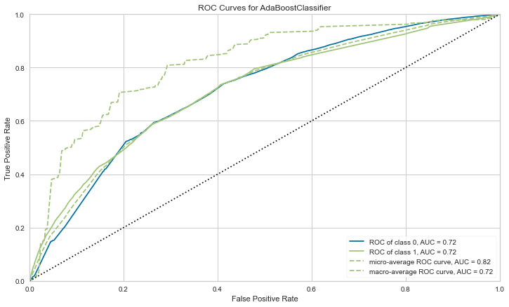

```python
plot_model(final_model, plot = 'auc')
```

### Confusion Matrix

Despite of the promising result in the **AUC** plot, the **Confusion Matrix** reveals that capability of spotting buying event is troublesome

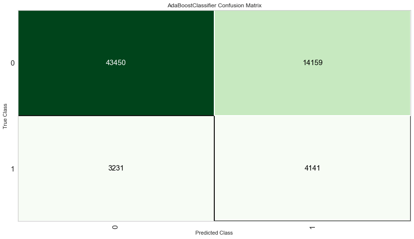

```python
plot_model(final_model, plot = 'confusion_matrix')
```